# Text Analysis of Inaugural Addresses

Sumer Gupta

University of Essex

2026-03-29

```r
library(quanteda)
library(quanteda.textmodels)
library(quanteda.textstats)
library(ggplot2)
library(tidyverse)
library(caret)
```

## Introduction

A politician’s partisan identity doesn’t just shape what the politician would say, but also shapes how they say it - the vocabulary, tone and rhetoric employed. The US presidential inaugural address offers fertile ground for testing this claim as they are one of the most formally preserved political texts. By training a supervised machine learning classifier to correctly identify the party affiliation of a US president purely from the linguistic features of their inaugural address.

## 1. Building and Exploring the Corpus

The dataset `data_corpus_inaugural` is directly built into the `quanteda` package, containing 59 inaugural addressess from the time of Washington (1789) to Biden (2021). However, since the modern two-party system solidified after 1860, we can create a subset from 1861 onwards - after which point the two-party competition between Republican and Democrat goes on until the present.

```r
#Load the built-in dataset

data("data_corpus_inaugural", package = "quanteda")

# Create a subset for the two-party era

modern_corpus <- data_corpus_inaugural[
  docvars(data_corpus_inaugural, "Year") >= 1861 &
  docvars(data_corpus_inaugural, "Year") <= 2021
]

# Assign party labels using historical records.

years <- docvars(modern_corpus, "Year")


parties <- case_when(
  years %in% c(1861, 1865, 1869, 1873, 1877, 1881, 1889, 1897,
               1901, 1905, 1909, 1921, 1925, 1929, 1953, 1957,
               1969, 1973, 1981, 1985, 1989, 2001, 2005, 2017) ~ "Republican",
  years %in% c(1885, 1893, 1913, 1917, 1933, 1937, 1941, 1945,
               1949, 1961, 1965, 1977, 1993, 1997, 2009, 2013, 2021) ~ "Democrat"
)

docvars(modern_corpus, "Party") <- parties # docvars() attach party labels back to the corpus providing a digital tag of political affiliation.

# Create a summary  of the Corpus

summary(modern_corpus)[, c("Text", "Types", "Tokens", "Sentences",
                            "Year", "President", "Party")]
```

```
##               Text Types Tokens Sentences Year  President      Party
## 1     1861-Lincoln  1075   3999       135 1861    Lincoln Republican
## 2     1865-Lincoln   360    775        26 1865    Lincoln Republican
## 3       1869-Grant   485   1229        40 1869      Grant Republican
## 4       1873-Grant   552   1472        43 1873      Grant Republican
## 5       1877-Hayes   831   2707        59 1877      Hayes Republican
## 6    1881-Garfield  1021   3209       111 1881   Garfield Republican
## 7   1885-Cleveland   676   1816        44 1885  Cleveland   Democrat
## 8    1889-Harrison  1352   4721       157 1889   Harrison Republican
## 9   1893-Cleveland   821   2125        58 1893  Cleveland   Democrat
## 10   1897-McKinley  1232   4353       130 1897   McKinley Republican
## 11   1901-McKinley   854   2437       100 1901   McKinley Republican
## 12  1905-Roosevelt   404   1079        33 1905  Roosevelt Republican
## 13       1909-Taft  1437   5821       158 1909       Taft Republican
## 14     1913-Wilson   658   1882        68 1913     Wilson   Democrat
```

[output cut: 27 more lines]

The resulting corpus contains speeches, comprising of both Democrat and Republican addresses. Even though the count is slightly higher for the Republican party, the distribution is balanced enough to give a stable foundation for the model. This balance ensures that the classifier would not simply “default” to the most frequent party, enabling the statistical differences in vocabulary to drive the predictions.

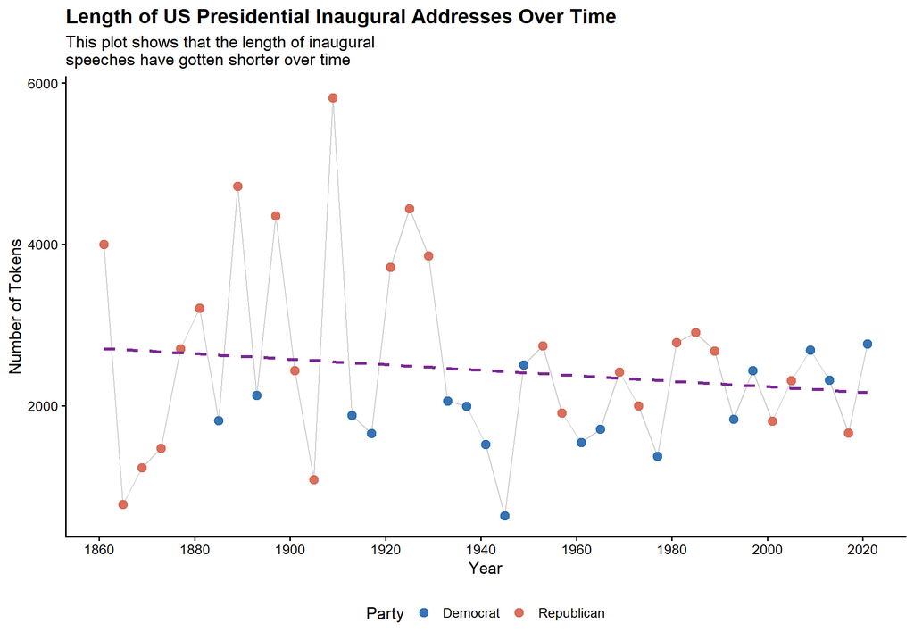

```r
# Create a data frame for the plot

token_df <- data.frame(
  year = docvars(modern_corpus, "Year"),
  tokens = ntoken(modern_corpus),
  party = docvars(modern_corpus, "Party"),
  president = docvars(modern_corpus, "President")
)

# Plot the number of tokens (individual units of text)

ggplot(token_df, aes(x = year, y = tokens, colour = party)) +
  geom_line(colour = "grey80", linewidth = 0.5, aes(group = 1)) +
  geom_point(size = 3, alpha = 0.9) +
  scale_colour_manual(values = c("Democrat" = "#2166AC", "Republican" = "#D6604D")) +
  geom_smooth(method = "lm", aes(group = 1), colour = "#7A2894", linetype = "dashed", se = FALSE) +
  scale_x_continuous(breaks = seq(1860, 2025, by = 20)) +
  labs(
    title    = "Length of US Presidential Inaugural Addresses Over Time",
    subtitle = "This plot shows that the length of inaugural \nspeeches have gotten shorter over time",
    x        = "Year",
    y        = "Number of Tokens",
    colour   = "Party"
  ) +
  theme_classic(base_size = 13) +
  theme(legend.position = "bottom",
        plot.title = element_text(face = "bold"))
```

## 2. Preprocessing Pipeline

This preprocessing pipeline transforms the raw speeches into a structured DFM (Document-Feature Matrix) by removing linguistic noise and standardising vocabulary. Through isolating root words and filtering out non-partisan “stopwords”, we can ensure that the model focuses on the particular ideological markers that distinguish the two parties.

This pipeline goes through 5 steps

1. *Tokenise and Clean*: Break the text into individual words while removing punctuation, numbers and symbols that don’t contribute to ideological meaning. Splitting hyphens allows us to ensure that compound terminology is captured by the component words.
2. *Stemming*: Through stemming words are reduced to their base form, for example: ‘democracy’ and ‘democratic’ become ‘democraci’. This groups related terms in order to give the model more consistent data points.
3. *Remove Stopwords*: Filter out common English stopwords like the, is, or at, that appear frequently but do not carry with them any ideological or thematic weight.
4. *Construct the DFM*: Convert the list of words into a mathematical grid where rows are speeches and columns represent word counts - this is the main format required for machine learning.
5. *Standardization*: Convert all text to lowercase so that the model doesn’t treat “Democracy” and “democracy” as two separate words.

```r
# 1. Tokenise and Clean

speech_tokens <- tokens(
  modern_corpus,
  remove_punct   = TRUE,
  remove_numbers = TRUE,
  remove_symbols = TRUE,
  split_hyphens  = TRUE
)

# 2. Stemming

speech_tokens <- tokens_wordstem(speech_tokens)

# 3. Remove Stopwords

speech_tokens <- tokens_remove(speech_tokens, pattern = stopwords("english"))

# 4. Construct the DFM

dfmat <- dfm(speech_tokens)

# 5. Standardization

dfmat <- dfm_tolower(dfmat)


dfmat
```

```
## Document-feature matrix of: 41 documents, 4,565 features (87.57% sparse) and 4 docvars.
##                features
## docs            fellow citizen unite state complianc custom old govern appear
##   1861-Lincoln       2       7     5    27         1      1   3     19      1
##   1865-Lincoln       1       0     0     0         0      0   0      1      1
##   1869-Grant         0       4     2     4         0      0   0      4      0
##   1873-Grant         1       2     0     4         0      0   1      5      0
##   1877-Hayes         4       8     2    12         1      1   0     20      1
##   1881-Garfield      2       7     7    16         0      0   0     24      0
##                features
## docs            befor
##   1861-Lincoln      7
##   1865-Lincoln      1
##   1869-Grant        3
##   1873-Grant        3
##   1877-Hayes        2
##   1881-Garfield     2
## [ reached max_ndoc ... 35 more documents, reached max_nfeat ... 4,555 more features ]
```

The DFM shows that the 41 addresses are condensed into `4,565` unique word stems, this provides a high-dimensional portrait of presidential rhetoric over 160 years. With a sparsity of `87.57%`, the DFM indicates that even though the total vocabulary is vast, each individual speech utilizes a very specific subset of terms, this is ideal for identifying the unique linguistic markers of each party. Each cell records how often a word stem appears in a given speech.

## 3. Keyness Analysis

Keyness analysis is a principled statistical test that identifies which word stems are most distinctively associated with each party in their inaugural addresses. Using the `textstat_keyness()` function from `quanteda.textstats` we compute a chi-squared ($\chi^{2}$) statistic for each feature, thereby measuring how significantly its frequency in the target group diverges from what we would expect if the party had no impact on word choice.

By comparing group-level frequencies, keyness analysis can tell us which stems are used disproportionately by one party across all their speeches.

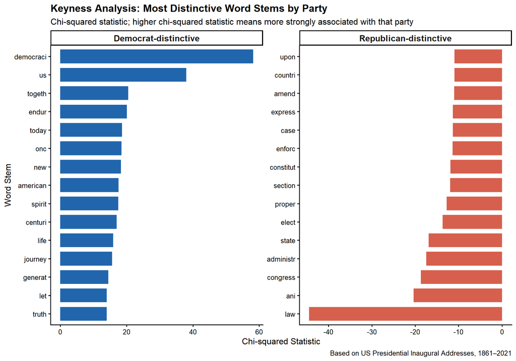

```r
# Compute keyness using Democrats as the target group and Republicans as reference

keyness <- textstat_keyness(dfmat,
                             target  = docvars(dfmat, "Party") == "Democrat",
                             measure = "chi2")

# Find the top 15 Democrat-distinctive and Republican-distinctive stems

top_dem <- head(keyness, 15)
top_rep <- tail(keyness, 15)

# Combine the two and label directions

plot_data <- bind_rows(
  mutate(top_dem, direction = "Democrat-distinctive"),
  mutate(top_rep, direction = "Republican-distinctive")
) %>%
  mutate(feature = reorder(feature, chi2))

# Plot the Keyness Analysis

ggplot(plot_data, aes(x = feature, y = chi2, fill = direction)) +
  geom_col(width = 0.75) +
  coord_flip() +
  facet_wrap(~ direction, scales = "free") +
  scale_fill_manual(values = c(
    "Democrat-distinctive"    = "#2166AC",
    "Republican-distinctive"  = "#D6604D"
  )) +
  labs(
    title    = "Keyness Analysis: Most Distinctive Word Stems by Party",
    subtitle = "Chi-squared statistic; higher chi-squared statistic means more strongly associated with that party",
    x        = "Word Stem",
    y        = "Chi-squared Statistic",
    caption  = "Based on US Presidential Inaugural Addresses, 1861–2021"
  ) +
  theme_classic(base_size = 12) +
  theme(
    legend.position = "none",
    strip.text      = element_text(face = "bold", size = 12),
    plot.title      = element_text(face = "bold")
  )
```

This keyness plot shows the substantively meaningful differences in the vocabulary used by both parties:

Democrat-distinctive stems show that Democratic presidents reach for the word “democraci” more than any other term. Their rhetoric centers around collective solidarity, with words like “us”, “togeth” and “journey”, and time, with words like “centuri”, “today” and “generat”.

Republican-distinctive stems are notably institutional and procedural. “law” is the strongest Republican-distinctive stem, followed by words like “congress”, “enforce”, “administr”, “state” and “constitut” - centering their language around the formal structures of government and constitutional order.

## 4. Naïve Bayes Classification

**Naïve Bayes** is a generative probabilistic classifier rooted in Bayes’ theorem:

$$P(\text{class} \mid \text{document}) =
P(\text{document} \mid \text{class}) \times
\frac{P(\text{class})}{P(\text{document})}$$

This makes two important assumptions: (1) the **bag-of-words assumption** states that word order doesn’t matter, only the frequency of a word used matters, and (2) the **conditional independence assumption** states that given the party, words are independent of each other. Both assumptions are technically false, however, they still produce a strong performance for classification in practice - this is true particularly for short texts wherein frequency signals prove to be informative.

To increase the training sample from 41 documents to a more robust dataset, one must reshape the corpus at the paragraph level. Each paragraph of each speech becomes its own document, and inherits the party label of its parent speech.

```r
# Rebuild the DFM and reshape to the paragraph level

para_corpus <- corpus_reshape(modern_corpus, to = "paragraphs", use_docvars = TRUE)

para_tokens <- tokens(para_corpus,
                      remove_punct   = TRUE,
                      remove_numbers = TRUE,
                      remove_symbols = TRUE,
                      split_hyphens  = TRUE) %>%
  tokens_wordstem() %>%
  tokens_remove(stopwords("english"))

para_dfm <- dfm(para_tokens) %>% dfm_tolower()

# Check the class distribution at the paragraph level

table(docvars(para_dfm, "Party"))
```

```
##
##   Democrat Republican
##        677        822
```

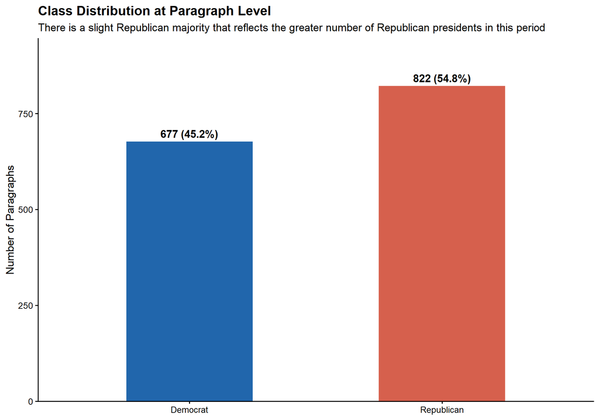

```r
# Create a new data frame that shows frequency and percentage distribution of speeches by political party.

party_counts <- as.data.frame(table(docvars(para_dfm, "Party")))
names(party_counts) <- c("Party", "Count")
party_counts$Proportion <- round(party_counts$Count / sum(party_counts$Count) * 100, 1)

# Create a plot to show the class distribution at the paragraph level
ggplot(party_counts, aes(x = Party, y = Count, fill = Party)) +
  geom_col(width = 0.5) +
  geom_text(aes(label = paste0(Count, " (", Proportion, "%)")),
            vjust = -0.5, size = 4.5, fontface = "bold") +
  scale_fill_manual(values = c("Democrat" = "#2166AC", "Republican" = "#D6604D")) +
  scale_y_continuous(expand = expansion(mult = c(0, 0.15))) +
  labs(
    title    = "Class Distribution at Paragraph Level",
    subtitle = "There is a slight Republican majority that reflects the greater number of Republican presidents in this period",
    x = NULL, y = "Number of Paragraphs"
  ) +
  theme_classic(base_size = 13) +
  theme(legend.position = "none",
        plot.title = element_text(face = "bold"))
```

Conduct a Train/Test (80/20) split to partition the data into two parts, whre one is used to learn the model parameters (training set) and the other is used to evaluate performance on unseen data (test set).

```r
set.seed(42) # for reproducibility

# Define the 80/20 split ratio for training and testing

n_docs  <- ndoc(para_dfm)
n_train <- floor(0.80 * n_docs)

# Shuffle indices to avoid temporal ordering bias

idx_shuffled <- sample(seq_len(n_docs))
train_idx    <- idx_shuffled[1:n_train]
test_idx     <- idx_shuffled[(n_train + 1):n_docs]

# Partition the data into training and validation sets

dfm_train <- para_dfm[train_idx, ]
dfm_test  <- para_dfm[test_idx,  ]

# Fit the Multinomial Naïve Bayes

nb_model <- textmodel_nb(dfm_train,
                          y            = docvars(dfm_train, "Party"),
                          distribution = "multinomial",
                          smooth       = 1)  # Laplace (add-1) smoothing

summary(nb_model)
```

```
##
## Call:
## textmodel_nb.dfm(x = dfm_train, y = docvars(dfm_train, "Party"),
##     smooth = 1, distribution = "multinomial")
##
## Class Priors:
## (showing first 2 elements)
##   Democrat Republican
##        0.5        0.5
##
## Estimated Feature Scores:
##             fellow  citizen    unite    state complianc    custom      old
## Democrat   0.00178 0.002885 0.001657 0.001842 6.138e-05 0.0001228 0.001535
## Republican 0.00102 0.002918 0.001793 0.004781 1.406e-04 0.0002813 0.001020
##              govern    appear    befor   address   briefli     take   presenc
## Democrat   0.005156 6.138e-05 0.001289 0.0003069 1.228e-04 0.001166 0.0003683
## Republican 0.008227 3.516e-04 0.002180 0.0002813 7.031e-05 0.001195 0.0003516
##                 oath  prescrib constitut     taken   presid     enter    execut
## Democrat   0.0013504 0.0001842  0.001105 0.0007980 0.001596 0.0001228 0.0005525
## Republican 0.0007031 0.0002109  0.003023 0.0007734 0.001477 0.0006328 0.0018282
##                offic    consid necessari   present   discuss    matter
## Democrat   0.0008594 0.0003069 0.0004297 0.0005525 0.0001228 0.0003069
## Republican 0.0013711 0.0003516 0.0010899 0.0010547 0.0003867 0.0007734
##            administr   special   anxieti
## Democrat   0.0003683 0.0004297 0.0003069
## Republican 0.0016524 0.0004922 0.0002109
```

An important practical consideration is that the test set may contain word stems that aren’t present in the training vocabulary, using `dfm_match()` we can align the test DFM to the training vocabulary, thereby removing unseen features and padding with zeros for features in training that are absent from the test paragraph.

```r
# Align the test DFM to the training vocabulary

dfm_test_matched <- dfm_match(dfm_test, features = featnames(dfm_train))

# Generate predictions

predicted_party <- predict(nb_model, newdata = dfm_test_matched)
actual_party <- docvars(dfm_test_matched, "Party")

predicted_party
```

[output not shown]

[output cut: 96 more lines]

[output not shown]

```r
actual_party
```

[output not shown]

[output cut: 45 more lines]

## 5. Model Evaluation

A confusion matrix is a 2x2 table that compares the predicted class labels against the actual labels.

```r
# Create the confusion matrix

tab <- table(Predicted = predicted_party, Actual = actual_party)
tab
```

```
##             Actual
## Predicted    Democrat Republican
##   Democrat         83         75
##   Republican       50         92
```

```r
cfm <- confusionMatrix(tab, mode = "everything")
cfm
```

```
## Confusion Matrix and Statistics
##
##             Actual
## Predicted    Democrat Republican
##   Democrat         83         75
##   Republican       50         92
##
##                Accuracy : 0.5833
##                  95% CI : (0.5253, 0.6397)
##     No Information Rate : 0.5567
##     P-Value [Acc > NIR] : 0.19186
##
##                   Kappa : 0.1717
##
##  Mcnemar's Test P-Value : 0.03182
##
##             Sensitivity : 0.6241
##             Specificity : 0.5509
##          Pos Pred Value : 0.5253
##          Neg Pred Value : 0.6479
##               Precision : 0.5253
##                  Recall : 0.6241
##                      F1 : 0.5704
##              Prevalence : 0.4433
##          Detection Rate : 0.2767
##    Detection Prevalence : 0.5267
##       Balanced Accuracy : 0.5875
##
##        'Positive' Class : Democrat
##
```

To better understand this, we can visualise the classification performance.

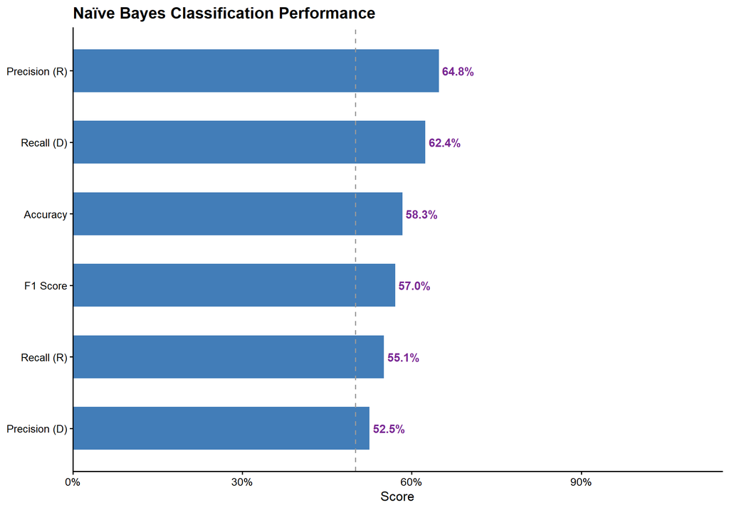

```r
# Extract the key metrics for plotting

metrics <- data.frame(
  Metric = c("Accuracy", "Precision (D)", "Recall (D)",
             "Precision (R)", "Recall (R)", "F1 Score"),
  Value  = c(
    cfm$overall["Accuracy"],
    cfm$byClass["Pos Pred Value"],
    cfm$byClass["Sensitivity"],
    cfm$byClass["Neg Pred Value"],
    cfm$byClass["Specificity"],
    cfm$byClass["F1"]
  )
)

# Create the plot

ggplot(metrics, aes(x = reorder(Metric, Value), y = Value)) +
  geom_col(fill = "#2166AC", alpha = 0.85, width = 0.6) +
  geom_text(aes(label = scales::percent(Value, accuracy = 0.1)),
            hjust = -0.1, size = 4, fontface = "bold", colour = "#7A2894") +
  coord_flip() +
  scale_y_continuous(labels = scales::percent_format(),
                     limits = c(0, 1.15),
                     expand = expansion(mult = c(0, 0))) +
  geom_hline(yintercept = 0.5, linetype = "dashed", colour = "grey60") +
  labs(
    title    = "Naïve Bayes Classification Performance",
    x = NULL, y = "Score"
  ) +
  theme_classic(base_size = 13) +
  theme(plot.title = element_text(face = "bold"))
```

The asymmetry between parties is noteworthy. When the model predicts Republican it is more often correct (Precision: 64.8%), but it catches a greater share of the actual Democrat paragraphs (Recall: 62.4%) — at the cost of more false positives. The F1-score of 57.0% highlights this uneven trade-off in a single number.